# FOR/STT 875, Exercise 7

## Learning objectives

- Introduce `with`, `tapply`, and `cut` functions
- Summarize data using the `table` function with logical subsetting
- Practice using factor data types

## Overview

Modify this R Markdown file by filling in the code needed to answer the questions.

## Submission instructions

Upload your exercise_7.Rmd and exercise_7.html files to the Exercise 7 D2L dropbox.

## Grading

You will receive full credit if your R Markdown document: 1) compiles without error; and 2) correctly completes the `# TODO:` code chunks. Also, please, fill in the feedback questions at the end of the exercise.

## Getting started

Again, set some global options to make the R code printed in the html output look nice.

```r
knitr::opts_chunk$set(comment = NA, tidy = TRUE)
```

### Three functions: `table`, `cut`, and `tapply`

The `table`, `cut`, and `tapply` functions are very handy for partitioning and summarizing data sets. We’ll use these functions to summarize World Bank data on life expectancy, GDP, fertility rate, population, etc., for countries over the years 1960-2014 (these data share some similarities with the `gapminder` data we have worked with previously). As of R 4.0.0, the `read.table` and related functions like `read.csv` do not assume character columns are factors by default (see, [R 4.0.0 r-devel news](https://cran.r-project.org/doc/manuals/r-devel/NEWS.html) and/or [The R Blog - R Developer Page](https://developer.r-project.org/Blog/public/2020/02/16/stringsasfactors/index.html) for the developers’ perspective on this change). For the subsequent analysis, we generally want character columns (i.e., variables) to be treated as factors, so we set the `stringsAsFactors` argument in the call to `read.csv` to `TRUE` (note, if we forgot to read these columns in as factors, we could always convert them to factors later in the code using, e.g., the `as.factor` function).

```r
WorldBank <- read.csv("http://www.finley-lab.com/files/data/WorldBank.csv", header = TRUE,
                      stringsAsFactors = TRUE)
str(WorldBank)
```

```
'data.frame':   11880 obs. of  15 variables:
 $ iso2c                       : Factor w/ 215 levels "AD","AE","AF",..: 1 1 1 1 1 1 1 1 1 1 ...
 $ country                     : Factor w/ 216 levels "Afghanistan",..: 5 5 5 5 5 5 5 5 5 5 ...
 $ year                        : int  1978 1979 1977 2007 1976 2011 2012 2008 1980 1972 ...
 $ fertility.rate              : num  NA NA NA 1.18 NA NA NA 1.25 NA NA ...
 $ life.expectancy             : num  NA NA NA NA NA NA NA NA NA NA ...
 $ population                  : num  33746 34819 32769 81292 31781 ...
 $ GDP.per.capita.Current.USD  : num  9128 11820 7751 39923 7152 ...
 $ X15.to.25.yr.female.literacy: num  NA NA NA NA NA NA NA NA NA NA ...
 $ iso3c                       : Factor w/ 213 levels "ABW","AFG","AGO",..: 5 5 5 5 5 5 5 5 5 5 ...
 $ region                      : Factor w/ 7 levels "East Asia & Pacific (all income levels)",..: 2 2 2 2 2 2 2 2 2 2 ...
 $ capital                     : Factor w/ 209 levels "","Abu Dhabi",..: 10 10 10 10 10 10 10 10 10 10 ...
 $ longitude                   : num  1.52 1.52 1.52 1.52 1.52 ...
 $ latitude                    : num  42.5 42.5 42.5 42.5 42.5 ...
 $ income                      : Factor w/ 6 levels "High income: nonOECD",..: 1 1 1 1 1 1 1 1 1 1 ...
 $ lending                     : Factor w/ 4 levels "Blend","IBRD",..: 4 4 4 4 4 4 4 4 4 4 ...
```

The region values in the data set are informative but lengthy.

```r
levels(WorldBank$region)
```

```
[1] "East Asia & Pacific (all income levels)"
[2] "Europe & Central Asia (all income levels)"
[3] "Latin America & Caribbean (all income levels)"
[4] "Middle East & North Africa (all income levels)"
[5] "North America"
[6] "South Asia"
[7] "Sub-Saharan Africa (all income levels)"
```

Let’s create a `region2` variable with shorter but less descriptive values, for simplicity.

```r
WorldBank$region2 <- WorldBank$region
levels(WorldBank$region2) <- c("EastAsia", "Europe", "LatAmer", "MideastAndNorthAfrica", "NorthAmer", "SouthAsia", "SubSaharanAfrica")
```

## The `table` function

We have seen the `table` function before. The `table` function returns a one, two, three, or higher dimensional contingency table. For example, we can try to tabulate the number of countries in each region.

```r
table(WorldBank$region2)
```

```
             EastAsia                Europe               LatAmer
                 1980                  3135                  2255
MideastAndNorthAfrica             NorthAmer             SouthAsia
                 1155                   165                   440
     SubSaharanAfrica
                 2585
```

Recall, tables can easily be sorted.

```r
sort(table(WorldBank$region2))
```

```
            NorthAmer             SouthAsia MideastAndNorthAfrica
                  165                   440                  1155
             EastAsia               LatAmer      SubSaharanAfrica
                 1980                  2255                  2585
               Europe
                 3135
```

```r
sort(table(WorldBank$region2), decreasing = TRUE)
```

```
               Europe      SubSaharanAfrica               LatAmer
                 3135                  2585                  2255
             EastAsia MideastAndNorthAfrica             SouthAsia
                 1980                  1155                   440
            NorthAmer
                  165
```

These tables aren’t quite what we wanted, however, since each country appears multiple times, once for each year. We need to divide by the number of unique years in the data set. First, calculate the number of unique years in the data set.

```r
#Number of unique years
n.years <- length(unique(WorldBank$year))
```

Now divide the original table by the number of unique years to obtain a table that counts each country only once.

```r
#Use table to tabulate the number of countries per region
sort(table(WorldBank$region2))/n.years
```

```
            NorthAmer             SouthAsia MideastAndNorthAfrica
                    3                     8                    21
             EastAsia               LatAmer      SubSaharanAfrica
                   36                    41                    47
               Europe
                   57
```

The `table` function can also take a logical vector as input. For example, we can tabulate the number of countries which have life expectancy less than or equal to, or greater than, 60 years.

```r
table(WorldBank$life.expectancy > 60)
```

```
FALSE  TRUE
 3683  6947
```

Here again countries are counted more than once, but that may be what is wanted in this case. In the first case it was more clear what the table was representing, but in this case `FALSE` and `TRUE` by themselves don’t provide much clarity. The `dnn` argument can be used to provide a label for the table. Don’t forget to look at the documentation for the `table` function (`?table`) if you are curious why the argument is labeled `dnn`.

```r
table(WorldBank$life.expectancy > 60, dnn = "Life Expectancy more than 60 years")
```

```
Life Expectancy more than 60 years
FALSE  TRUE
 3683  6947
```

Next we investigate the two-way frequency table relating life expectancy and region.

```r
table(WorldBank$region2, WorldBank$life.expectancy > 60)
```

```
                        FALSE TRUE
  EastAsia                445 1236
  Europe                   67 2676
  LatAmer                 287 1599
  MideastAndNorthAfrica   308  792
  NorthAmer                 0  126
  SouthAsia               251  181
  SubSaharanAfrica       2252  248
```

Again, labels would help. Create the same table, but use the `dnn` argument to add both row and column labels. (You’ll need to give a length two character vector as the value of `dnn`.)

```r
# TODO 7.1: Create the labeled two-way table here
table(WorldBank$region2, WorldBank$life.expectancy > 60, dnn = c("Region","Life Expectancy more than 60 years"))
```

```
                       Life Expectancy more than 60 years
Region                  FALSE TRUE
  EastAsia                445 1236
  Europe                   67 2676
  LatAmer                 287 1599
  MideastAndNorthAfrica   308  792
  NorthAmer                 0  126
  SouthAsia               251  181
  SubSaharanAfrica       2252  248
```

The `$` method of referring to a variable in a data frame can lead to messy code. The `with` function provides a sometimes preferable way to specify variables. Here is an example that creates the one-way frequency table of life expectancy using `with`.

```r
with(WorldBank, table(life.expectancy > 60, dnn = "Life Expectancy more than 60 years"))
```

```
Life Expectancy more than 60 years
FALSE  TRUE
 3683  6947
```

Next use `with` to create the two-way table of region and life expectancy with row and column labels.

```r
# TODO 7.2: Create the table here
with(WorldBank, table(region2, life.expectancy > 60, dnn = c("Region","Life Expectancy more than 60 years")))
```

```
                       Life Expectancy more than 60 years
Region                  FALSE TRUE
  EastAsia                445 1236
  Europe                   67 2676
  LatAmer                 287 1599
  MideastAndNorthAfrica   308  792
  NorthAmer                 0  126
  SouthAsia               251  181
  SubSaharanAfrica       2252  248
```

## Using `tapply`

Consider investigating mean life expectancy by region. For example we could compute the mean life expectancy by region.

```r
with(WorldBank, mean(life.expectancy[region2 == "EastAsia"]))
```

```
[1] NA
```

The function returned `NA` since there are some missing observations. Add the argument `na.rm = TRUE` to the mean function to get the mean of the non-missing observations.

```r
# TODO 7.3: Compute the mean of the non-missing life expectancies for EastAsia here
with(WorldBank, mean(life.expectancy[region2 == "EastAsia"], na.rm=TRUE))
```

```
[1] 65.09366
```

We could continue in this way:

```r
with(WorldBank, mean(life.expectancy[region2 == "Europe"], na.rm = TRUE))
```

```
[1] 71.6237
```

```r
with(WorldBank, mean(life.expectancy[region2 == "LatAmer"], na.rm = TRUE))
```

```
[1] 67.3561
```

Etc.

But there’s an easier way, using the `tapply` function.

```r
with(WorldBank, tapply(X = life.expectancy, INDEX = region2, FUN = mean, na.rm = TRUE ))
```

```
             EastAsia                Europe               LatAmer
             65.09366              71.62370              67.35610
MideastAndNorthAfrica             NorthAmer             SouthAsia
             65.30479              75.64064              56.06903
     SubSaharanAfrica
             49.63768
```

The function `tapply` takes an “atomic object” (typically a vector) as the argument `X`, a list of one or more factors of the same length as `X` as the `INDEX`, a function as the `FUN`, and possibly arguments to the function such as `na.rm = TRUE`.

Here a second factor `income` is added.

```r
with(WorldBank, tapply(X = life.expectancy, INDEX = list(region2, income), FUN = mean, na.rm = TRUE ))
```

```
                      High income: nonOECD High income: OECD Low income
EastAsia                          71.82818          74.33210   56.91181
Europe                            74.32839          74.49562   63.39652
LatAmer                           71.43276                NA   52.94133
MideastAndNorthAfrica             68.94796          76.05284         NA
NorthAmer                         77.44577          75.33979         NA
SouthAsia                               NA                NA   52.36452
SubSaharanAfrica                  44.63917                NA   47.47993
                      Lower middle income Not classified
EastAsia                         60.36460             NA
Europe                           67.05043             NA
LatAmer                          62.68671             NA
MideastAndNorthAfrica            60.60664             NA
NorthAmer                              NA             NA
SouthAsia                        58.42655             NA
SubSaharanAfrica                 51.13590       42.71714
                      Upper middle income
EastAsia                         67.34460
Europe                           68.95677
LatAmer                          68.62220
MideastAndNorthAfrica            64.44193
NorthAmer                              NA
SouthAsia                        57.75247
SubSaharanAfrica                 58.80324
```

- $23.5 \leq \text{lat} \leq 66.5$: Northern temperate
- $0 \leq \text{lat} < 23.5$: Northern tropics
- $-23.5 \leq \text{lat} < 0$: Southern tropics
- $-66.5 \leq \text{lat} < -23.5$: Southern temperate

(The frigid zones are omitted since none of the countries in the data set lie in these zones.)

We can compute the mean life expectancy in each zone using logical subsetting. For example, here we compute the mean life expectancy in the northern tropics. (We’re also averaging over years, of course.)

```r
with(WorldBank, mean(life.expectancy[0 <= latitude & latitude < 23.5], na.rm = TRUE))
```

```
[1] 59.16512
```

Next, calculate the mean life expectancy for the southern tropics.

```r
# TODO 7.4: Compute the mean life expectancy for the southern tropics here
with(WorldBank, mean(life.expectancy[-23.5 <= latitude & latitude < 0], na.rm = TRUE))
```

```
[1] 56.51467
```

We could continue in this way, but there is an easier way, using the `cut` function to create the factor we want.

First let’s look at cut in a simple context.

```r
x <- 0:50
cut(x, breaks = c(0, 10, 20, 30, 40, 50))
```

```
 [1] <NA>    (0,10]  (0,10]  (0,10]  (0,10]  (0,10]  (0,10]  (0,10]
 [9] (0,10]  (0,10]  (0,10]  (10,20] (10,20] (10,20] (10,20] (10,20]
[17] (10,20] (10,20] (10,20] (10,20] (10,20] (20,30] (20,30] (20,30]
[25] (20,30] (20,30] (20,30] (20,30] (20,30] (20,30] (20,30] (30,40]
[33] (30,40] (30,40] (30,40] (30,40] (30,40] (30,40] (30,40] (30,40]
[41] (30,40] (40,50] (40,50] (40,50] (40,50] (40,50] (40,50] (40,50]
[49] (40,50] (40,50] (40,50]
Levels: (0,10] (10,20] (20,30] (30,40] (40,50]
```

```r
cut(x, breaks = c(0, 10, 20, 30, 40, 50), include.lowest = TRUE)
```

```
 [1] [0,10]  [0,10]  [0,10]  [0,10]  [0,10]  [0,10]  [0,10]  [0,10]
 [9] [0,10]  [0,10]  [0,10]  (10,20] (10,20] (10,20] (10,20] (10,20]
[17] (10,20] (10,20] (10,20] (10,20] (10,20] (20,30] (20,30] (20,30]
[25] (20,30] (20,30] (20,30] (20,30] (20,30] (20,30] (20,30] (30,40]
[33] (30,40] (30,40] (30,40] (30,40] (30,40] (30,40] (30,40] (30,40]
[41] (30,40] (40,50] (40,50] (40,50] (40,50] (40,50] (40,50] (40,50]
[49] (40,50] (40,50] (40,50]
Levels: [0,10] (10,20] (20,30] (30,40] (40,50]
```

```r
cut(x, breaks = c(0, 10, 20, 30, 40, 50), right = FALSE)
```

```
 [1] [0,10)  [0,10)  [0,10)  [0,10)  [0,10)  [0,10)  [0,10)  [0,10)
 [9] [0,10)  [0,10)  [10,20) [10,20) [10,20) [10,20) [10,20) [10,20)
[17] [10,20) [10,20) [10,20) [10,20) [20,30) [20,30) [20,30) [20,30)
[25] [20,30) [20,30) [20,30) [20,30) [20,30) [20,30) [30,40) [30,40)
[33] [30,40) [30,40) [30,40) [30,40) [30,40) [30,40) [30,40) [30,40)
[41] [40,50) [40,50) [40,50) [40,50) [40,50) [40,50) [40,50) [40,50)
[49] [40,50) [40,50) <NA>
Levels: [0,10) [10,20) [20,30) [30,40) [40,50)
```

```r
cut(x, breaks = c(0, 10, 20, 30, 40, 50), right = FALSE, include.lowest = TRUE)
```

```
 [1] [0,10)  [0,10)  [0,10)  [0,10)  [0,10)  [0,10)  [0,10)  [0,10)
 [9] [0,10)  [0,10)  [10,20) [10,20) [10,20) [10,20) [10,20) [10,20)
[17] [10,20) [10,20) [10,20) [10,20) [20,30) [20,30) [20,30) [20,30)
[25] [20,30) [20,30) [20,30) [20,30) [20,30) [20,30) [30,40) [30,40)
[33] [30,40) [30,40) [30,40) [30,40) [30,40) [30,40) [30,40) [30,40)
[41] [40,50] [40,50] [40,50] [40,50] [40,50] [40,50] [40,50] [40,50]
[49] [40,50] [40,50] [40,50]
Levels: [0,10) [10,20) [20,30) [30,40) [40,50]
```

```r
cut(x, breaks = c(0, 10, 20, 30, 40, 50), labels = c("low", "midlow", "mid", "midhigh", "high"), include.lowest = TRUE)
```

```
 [1] low     low     low     low     low     low     low     low
 [9] low     low     low     midlow  midlow  midlow  midlow  midlow
[17] midlow  midlow  midlow  midlow  midlow  mid     mid     mid
[25] mid     mid     mid     mid     mid     mid     mid     midhigh
[33] midhigh midhigh midhigh midhigh midhigh midhigh midhigh midhigh
[41] midhigh high    high    high    high    high    high    high
[49] high    high    high
Levels: low midlow mid midhigh high
```

As we can see, `cut` divides the range of our vector into intervals and labels each vector member accordingly. By default, the divisions are labeled by the range (like `[0,10)`), but the `labels` argument can take in a custom vector of labels.

Now use `tapply` to calculate mean life expectancy by latitude region, with `cut` defining the factor which will separate countries into northern temperate, northern tropical, southern tropical, and southern temperate regions. Include appropriate labels for the latitude regions. Which latitudinal region has the highest and lowest mean life expectancy?

```r
# TODO 7.5: Calculate the mean life expectancies here
x <- cut(WorldBank$latitude, breaks = c(-66.5, -23.5, 0, 23.5, 66.5), include.lowest = TRUE, right = FALSE, labels=c("Southern temperate","Southern tropics","Northern tropics", "Northern temperate"))

with(WorldBank, tapply(X = life.expectancy, INDEX = x, FUN = mean, na.rm = TRUE ))
```

```
Southern temperate   Southern tropics   Northern tropics
          62.55977           56.51467           59.16512
Northern temperate
          68.97819
```

## Challenge Question

This question **will not be graded** and is provided for additional practice building your `R` skills. This is a *challenge* question, and thus not all material has been (or will be) covered.

[Principal components analysis](https://en.wikipedia.org/wiki/Principal_component_analysis) (PCA) is a statistical technique used for data reduction. In practice, we often see PCA used when a researcher wishes to find a reduced set of composite variables that explain much of the variability in a larger set of potentially correlated variables. The reduced set of composite variables are called the principal components (PCs) and are derived in such a way as to maximize the variance explained in the larger set of variables. These PCs can be used in [exploratory data analysis](https://en.wikipedia.org/wiki/Exploratory_data_analysis) (EDA) and/or as explanatory variables in a regression setting (e.g., [principal components regression](https://en.wikipedia.org/wiki/Principal_component_regression)). From an EDA perspective, consider the setting where you wish to understand if there are differences among groups defined by some characteristic (e.g., health or socioeconomic status, treatment, or geographic region) based on a large set of potentially correlated variables. Most EDAs start with simple graphics and other data visualization tools, but trying to detect group patters across a large number of variables can be challenging. Hence, if we can *distill* the large set of potentially redundant variables into PCs that capture the dominant characteristics in two or three derived variables, then visualization of group patterns becomes much more manageable. This idea motivates the challenge question.

Here, we ask you to perform a PCA on the following variables in the `WorldBank` data set: `fertility.rate`, `life.expectancy`, `population`, `GDP.per.capita.Current.USD`, and `X15.to.25.yr.female.literacy`. Many of these variables are correlated, and thus we could potentially use PCA to reduce the number of variables we are looking at by considering a set of composite “socioeconomic variables”, i.e., PCs. You should perform a PCA on these variables, assess the results of the PCA, and then produce a biplot for the first two PCs showing how the different regions are related to each other in terms of these components by plotting the points with different colors for each region. Consider following these steps:

1. Install and load the `ggbiplot` package for producing a biplot. Note: this will also install a couple other packages if they aren’t already installed, including `ggplot2`. If `ggbiplot` is not available via CRAN then you can install the development version from https://github.com/vqv/ggbiplot.
2. Subset the `WorldBank` data set to only grab the variables you will include in the PCA, as well as the `region2` variable. You will also want to remove any rows of these variables that contain any `NA` values (as PCA does not accommodate `NA`s). I find the `na.omit` function useful for this.
3. Perform the PCA using the `prcomp` function. You will want to make sure to center and scale the variables.
4. Use the `summary` function to assess results of the PCA.
5. Use the `ggbiplot` function to produce a plot of the first principal component vs the second principal component. Plot the points in the graph so that each region has a different color.
6. Interpret the results.

```r
library(ggbiplot)
pca.wb <- na.omit(WorldBank[, c('fertility.rate', 'life.expectancy',
                                'population', 'GDP.per.capita.Current.USD',
                                'X15.to.25.yr.female.literacy', 'region2')])
out.pca <- prcomp(pca.wb[, -ncol(pca.wb)],
                 center = TRUE,
                 scale. = TRUE)
summary(out.pca)
```

```
Importance of components:
                          PC1    PC2    PC3     PC4     PC5
Standard deviation     1.6729 1.0212 0.8684 0.48898 0.40643
Proportion of Variance 0.5597 0.2086 0.1508 0.04782 0.03304
Cumulative Proportion  0.5597 0.7683 0.9191 0.96696 1.00000
```

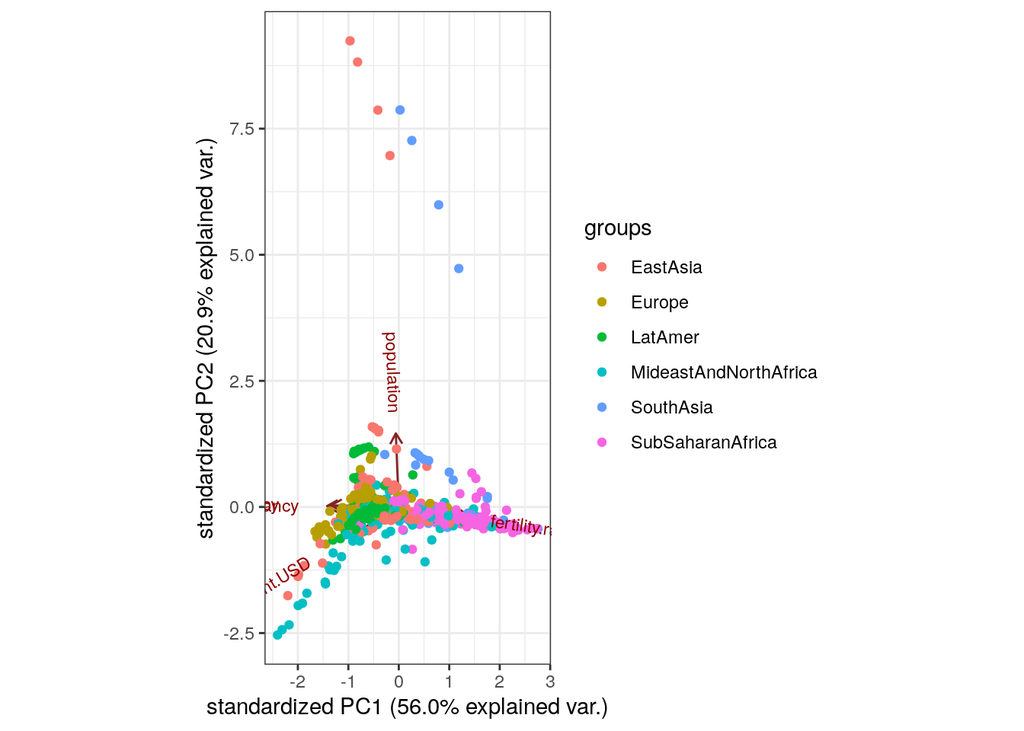

```r
ggbiplot(out.pca, groups = pca.wb$region2) +
  theme_bw()
```

Congratulations! You’ve reached the end of Exercise 7.

### Questions?

If you have any lingering questions about the material in this document or in the corresponding chapter, put them here.

*Response…*

### Give us your feedback!

1. How do you feel you’re doing in this class?

*Response…*

2. What could be done to improve your learning experience?

*Response…*